## Data Preprocessing Tasks

#### 1. Detecting and handling outliers for all the numerical features in the dataset using either the Z-score approach.

```python
import pandas as pd
import numpy as np

# loading the dataset
cdt = pd.read_csv(r"C:\Users\Varshan\OneDrive\Documents\AI\CSCN8000\creditcard.csv")
```

```python
import pandas as pd
from scipy.stats import zscore

# Extract numerical features (excluding 'Time', 'Amount', and 'Class')
numerical_features = cdt.drop(['Time', 'Amount', 'Class'], axis=1)

# Calculate Z-scores for each numerical feature
z_scores = zscore(numerical_features)

# Set a Z-score threshold
z_score_threshold = 3

# Identify and handle outliers by removing or transforming them
outliers = (abs(z_scores) > z_score_threshold).any(axis=1)
cdt_no_outliers = cdt[~outliers]

# Check the shape of the resulting DataFrame after handling outliers
print("Shape before handling outliers:", df.shape)
print("Shape after handling outliers:", cdt_no_outliers.shape)
print(f"Number of outliers removed: {sum(outliers)}")
```

```
Shape before handling outliers: (284807, 31)
Shape after handling outliers: (248171, 31)
Number of outliers removed: 36636
```

#### 2. Normalizing numerical features using appropriate method based on feature characteristics.

```python
from sklearn.preprocessing import MinMaxScaler

# Extract numerical features for normalization
numerical_features = cdt_no_outliers.drop(['Time', 'Amount', 'Class'], axis=1)

# Normalize numerical features using Min-Max scaling
scaler = MinMaxScaler()
cdt_no_outliers.loc[:, numerical_features.columns] = scaler.fit_transform(numerical_features)

# Check the DataFrame after normalization
display("DataFrame after normalization:")
display(cdt_no_outliers)
```

```
'DataFrame after normalization:'
```

|  | Time | V1 | V2 | V3 | V4 | V5 | V6 | V7 | V8 | V9 | ... | V21 | V22 | V23 | V24 | V25 | V26 | V27 | V28 | Amount | Class |
| --- | --- | --- | --- | --- | --- | --- | --- | --- | --- | --- | --- | --- | --- | --- | --- | --- | --- | --- | --- | --- | --- |
| 0 | 0.0 | 0.541886 | 0.492567 | 0.818747 | 0.662058 | 0.457545 | 0.554098 | 0.529567 | 0.513182 | 0.555032 | ... | 0.493521 | 0.564291 | 0.468623 | 0.587906 | 0.541068 | 0.433514 | 0.555039 | 0.489320 | 149.62 | 0 |
| 1 | 0.0 | 0.848317 | 0.526804 | 0.544342 | 0.552513 | 0.505796 | 0.485369 | 0.486410 | 0.511282 | 0.461041 | ... | 0.446193 | 0.353619 | 0.525421 | 0.460959 | 0.553420 | 0.542631 | 0.496164 | 0.507408 | 2.69 | 0 |
| 3 | 1.0 | 0.589146 | 0.481208 | 0.732675 | 0.398038 | 0.497278 | 0.653116 | 0.529297 | 0.552144 | 0.289275 | ... | 0.472992 | 0.501638 | 0.447207 | 0.200143 | 0.706966 | 0.422147 | 0.525781 | 0.531035 | 123.50 | 0 |
| 4 | 2.0 | 0.566094 | 0.588583 | 0.704390 | 0.547199 | 0.449203 | 0.507862 | 0.577460 | 0.461571 | 0.623938 | ... | 0.495546 | 0.683921 | 0.461386 | 0.611106 | 0.434096 | 0.673012 | 0.590503 | 0.608738 | 69.99 | 0 |
| 5 | 2.0 | 0.654032 | 0.596946 | 0.657194 | 0.479907 | 0.549521 | 0.492009 | 0.561636 | 0.535773 | 0.413493 | ... | 0.450190 | 0.371743 | 0.491174 | 0.451103 | 0.425531 | 0.535710 | 0.604721 | 0.540955 | 3.67 | 0 |
| ... | ... | ... | ... | ... | ... | ... | ... | ... | ... | ... | ... | ... | ... | ... | ... | ... | ... | ... | ... | ... | ... |
| 284800 | 172784.0 | 0.950118 | 0.482218 | 0.386486 | 0.527357 | 0.497471 | 0.404091 | 0.499402 | 0.482860 | 0.565903 | ... | 0.436550 | 0.335565 | 0.578164 | 0.454742 | 0.399051 | 0.568686 | 0.466490 | 0.462011 | 2.68 | 0 |
| 284801 | 172785.0 | 0.719635 | 0.593964 | 0.461843 | 0.411961 | 0.635442 | 0.465988 | 0.607249 | 0.515474 | 0.468838 | ... | 0.426020 | 0.314577 | 0.511757 | 0.599101 | 0.360598 | 0.542002 | 0.589891 | 0.534748 | 2.69 | 0 |
| 284803 | 172787.0 | 0.617185 | 0.494355 | 0.760700 | 0.412727 | 0.603695 | 0.629297 | 0.500389 | 0.540603 | 0.588580 | ... | 0.546562 | 0.712908 | 0.501597 | 0.249873 | 0.305999 | 0.362109 | 0.528156 | 0.472902 | 24.79 | 0 |
| 284804 | 172788.0 | 0.935708 | 0.469488 | 0.148792 | 0.434019 | 0.817162 | 0.878206 | 0.456859 | 0.598409 | 0.565455 | ... | 0.550631 | 0.633340 | 0.488196 | 0.766794 | 0.584940 | 0.468757 | 0.501714 | 0.486535 | 67.88 | 0 |
| 284806 | 172792.0 | 0.641129 | 0.480753 | 0.606504 | 0.440092 | 0.497007 | 0.413800 | 0.710842 | 0.441426 | 0.573610 | ... | 0.557250 | 0.648246 | 0.599312 | 0.569765 | 0.348518 | 0.215580 | 0.498877 | 0.506864 | 217.00 | 0 |

248171 rows × 31 columns

## Descriptive analytics Task

#### 1.Analyzing the distribution of fraud vs non-fraud transactions.

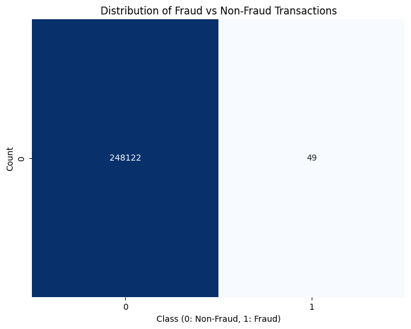

```python
import matplotlib.pyplot as plt
import seaborn as sns

# Assuming cdt_no_outliers is the DataFrame after preprocessing
fraud_distribution = cdt_no_outliers['Class'].value_counts()

# Create a heatmap
fig, ax = plt.subplots(figsize=(8, 6))
sns.heatmap(data=fraud_distribution.values.reshape(1, -1), cmap='Blues', annot=True, cbar=False, fmt='d')

ax.set(title='Distribution of Fraud vs Non-Fraud Transactions',
       xlabel='Class (0: Non-Fraud, 1: Fraud)', ylabel='Count')

plt.show()
```

#### The distribution is severely imbalanced as the distribution of fraud transaction is 49 while the distribution of non-fraud transaction is 248122

#### 2.Analyzing the correlation between fraud/non-fraud transactions and all the other numerical features.

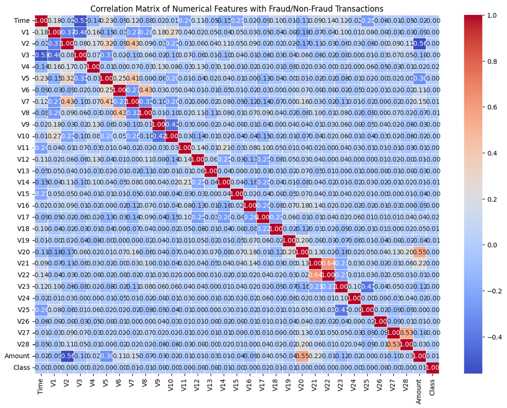

```
'Correlation with the target variable (Class):\n'
```

```
Class     1.000000
V4        0.016318
V17       0.015403
V18       0.007681
Amount    0.007282
V7        0.007102
V25       0.004172
V11       0.003966
V20       0.003948
V23       0.003935
V16       0.003374
V5        0.003242
V22       0.002437
V21       0.001283
V28       0.000767
V2        0.000707
V1        0.000588
V6       -0.000458
V24      -0.000778
V9       -0.001042
V27      -0.001410
V15      -0.001957
Time     -0.002914
V3       -0.002922
V26      -0.003527
V10      -0.004581
V13      -0.004613
V12      -0.004834
V19      -0.005925
V8       -0.006732
V14      -0.014320
Name: Class, dtype: float64
```

```python
# Calculate correlation matrix
correlation_matrix = cdt_no_outliers.corr()

# Plot a heatmap to visualize the correlation matrix
plt.figure(figsize=(14, 10))
sns.heatmap(correlation_matrix, cmap='coolwarm', annot=True, fmt=".2f", linewidths=0.5)
plt.title('Correlation Matrix of Numerical Features with Fraud/Non-Fraud Transactions')
plt.show()

# To comment on features with highest correlation
target_correlation = correlation_matrix['Class'].sort_values(ascending=False)
display("Correlation with the target variable (Class):\n", target_correlation)
```

#### a. Comment:

#### The strongest positive correlation is on the V4 with a correlation of 0.016318, suggesting a slight positive association with fraud.

#### The strongest negative correlation is on the V14 with a correlation of -0.014320, suggesting a weak negative association with fraud.

#### 3. From the previous step, choose the 10 features with highest correlation with the target variable, and plot their distributions against the fraud/non-fraud transactions

[figure not shown]

```python
# Choose the top 10 features with the highest correlation
top_features = target_correlation.abs().sort_values(ascending=False)[1:11].index

# Plot the distributions for each feature against fraud/non-fraud transactions
plt.figure(figsize=(16, 10))

for i, feature in enumerate(top_features, 1):
    plt.subplot(3, 4, i)
    sns.histplot(data=cdt_no_outliers, x=feature, hue='Class', bins=30, kde=True, palette='Set1')
    plt.title(f'Distribution of {feature} for Fraud/Non-Fraud Transactions')

plt.tight_layout()
plt.show()
```

## ML Model Training and Testing Tasks

#### 1. Split the cleaned data into training and testing sets (e.g., 80% training, 20% testing).

```python
from sklearn.model_selection import train_test_split

# Assuming 'Class' is the target variable
X = cdt_no_outliers.drop('Class', axis=1)  # Features
y = cdt_no_outliers['Class']  # Target variable

# Split the data into 80% training and 20% testing
X_train, X_test, y_train, y_test = train_test_split(X, y, test_size=0.2, random_state=42)

# Check the shape of the resulting sets
print("Training set shape:", X_train.shape, y_train.shape)
print("Testing set shape:", X_test.shape, y_test.shape)
```

```
Training set shape: (198536, 30) (198536,)
Testing set shape: (49635, 30) (49635,)
```

#### 2 .Use 5-fold cross-validation to train and validate the performance of all the models in this section.

```python
from sklearn.metrics import accuracy_score, precision_score, recall_score, f1_score, roc_auc_score
from sklearn.model_selection import cross_val_predict

# ... (previous code for training and testing the logistic regression model)

# Calculate metrics on the test set
accuracy = accuracy_score(y_test, y_pred)
precision = precision_score(y_test, y_pred, zero_division=1)  # Adding zero_division parameter
recall = recall_score(y_test, y_pred)
f1 = f1_score(y_test, y_pred)
roc_auc = roc_auc_score(y_test, y_pred)

print("Test Set Metrics:")
print(f"Accuracy: {accuracy:.4f}")
print(f"Precision: {precision:.4f}")
print(f"Recall: {recall:.4f}")
print(f"F1-Score: {f1:.4f}")
print(f"ROC AUC: {roc_auc:.4f}")


# Calculate cross-validated metrics
cv_accuracy = accuracy_score(y, y_cv_pred)
cv_precision = precision_score(y, y_cv_pred, zero_division=1)  # Adding zero_division parameter
cv_recall = recall_score(y, y_cv_pred)
cv_f1 = f1_score(y, y_cv_pred)
cv_roc_auc = roc_auc_score(y, y_cv_pred)

print("\nCross-Validated Metrics:")
print(f"Accuracy: {cv_accuracy:.4f}")
print(f"Precision: {cv_precision:.4f}")
print(f"Recall: {cv_recall:.4f}")
print(f"F1-Score: {cv_f1:.4f}")
print(f"ROC AUC: {cv_roc_auc:.4f}")
```

```
Test Set Metrics:
Accuracy: 0.9997
Precision: 1.0000
Recall: 0.0000
F1-Score: 0.0000
ROC AUC: 0.5000

Cross-Validated Metrics:
Accuracy: 0.9998
Precision: 0.0000
Recall: 0.0000
F1-Score: 0.0000
ROC AUC: 0.5000
```

#### 3. Train a logistic regression model as a baseline model.

```python
from sklearn.model_selection import cross_val_score, KFold
from sklearn.linear_model import LogisticRegression
from sklearn.ensemble import RandomForestClassifier
from sklearn.preprocessing import StandardScaler
from sklearn.pipeline import make_pipeline

# Extract features and labels
X, y = cdt_no_outliers.drop('Class', axis=1), cdt_no_outliers['Class']

# Combine preprocessing and model into a pipeline for Logistic Regression
logistic_model = make_pipeline(StandardScaler(), LogisticRegression())

# Use 5-fold cross-validation for Logistic Regression
cv = KFold(n_splits=5, shuffle=True, random_state=42)
logistic_cross_val_results = cross_val_score(logistic_model, X, y, cv=cv, scoring='accuracy')

# Print the cross-validation results for Logistic Regression
print("Logistic Regression Cross-Validation Results:")
print(logistic_cross_val_results)
print(f"Average Accuracy: {logistic_cross_val_results.mean()}")
```

```
Logistic Regression Cross-Validation Results:
[0.99967765 0.99991941 0.99973808 0.99981867 0.99985897]
Average Accuracy: 0.9998025559993277
```

#### 4. Print the coefficients of the logistic regression model. Comment on which feature the model gave higher weight to.

```python
from sklearn.linear_model import LogisticRegression
from sklearn.preprocessing import StandardScaler
from sklearn.pipeline import make_pipeline

# Inspect the columns of the dataset to ensure 'Class' exists
print(cdt_no_outliers.columns)

# Check if 'Class' exists in the dataset
if 'Class' in cdt_no_outliers.columns:
    # Extract features and labels
    X, y = cdt_no_outliers.drop('Class', axis=1), cdt_no_outliers['Class']

    # Combine preprocessing and model into a pipeline
    model = make_pipeline(StandardScaler(), LogisticRegression())

    # Fit the model on the entire dataset
    model.fit(X, y)

    # Get the learned coefficients
    coefficients = model.named_steps['logisticregression'].coef_[0]

    # Pair feature names with coefficients and print
    feature_coefficients = list(zip(X.columns, coefficients))
    for feature, coefficient in feature_coefficients:
        print(f"{feature}: {coefficient}")

    # Identify the feature with the highest weight
    max_feature = max(feature_coefficients, key=lambda x: abs(x[1]))
    print(f"\nFeature with the highest weight: {max_feature[0]} (Weight: {max_feature[1]})")
else:
    print("'Class' not found in the dataset.")
```

```
Index(['Time', 'V1', 'V2', 'V3', 'V4', 'V5', 'V6', 'V7', 'V8', 'V9', 'V10',
       'V11', 'V12', 'V13', 'V14', 'V15', 'V16', 'V17', 'V18', 'V19', 'V20',
       'V21', 'V22', 'V23', 'V24', 'V25', 'V26', 'V27', 'V28', 'Amount',
       'Class'],
      dtype='object')
Time: -0.565732227049894
V1: 1.0162773325677934
V2: -0.4234337291350053
V3: 0.5651210191800518
V4: 1.1048246648879498
V5: 0.5482890456463902
V6: 0.08909206423899607
V7: 0.16450163646061702
V8: -0.523422794482903
V9: -0.5060196774468934
V10: -0.7571991025939522
V11: 0.20312388129685743
V12: -0.34123519255643053
V13: -0.33126942835671386
V14: -0.4986149788210994
V15: -0.08622107961081509
V16: -0.040634941950661765
V17: 0.25686602068277353
V18: 0.30503905434722334
V19: 0.015439901401793186
V20: -0.2203007811995253
V21: 0.10234882173376621
V22: 0.43167378851210714
V23: 0.2623159528933794
V24: -0.011190446760195117
V25: 0.05331078515806697
V26: -0.36503061721581503
V27: -0.11463710771195386
V28: -0.02794959409053538
Amount: 0.40958159962556107

Feature with the highest weight: V4 (Weight: 1.1048246648879498)
```

#### 5. Evaluate the model's performance on the test set using the following metrics:

```python
from sklearn.metrics import accuracy_score, precision_score, recall_score, f1_score, confusion_matrix

# Assuming 'X_test' and 'y_test' are your test set features and labels
X_test, y_test = cdt_no_outliers.drop('Class', axis=1), cdt_no_outliers['Class']

# Predict the labels on the test set
y_pred = model.predict(X_test)

# Calculate metrics
accuracy = accuracy_score(y_test, y_pred)
precision = precision_score(y_test, y_pred, zero_division=0)
recall = recall_score(y_test, y_pred, zero_division=0)
f1 = f1_score(y_test, y_pred, zero_division=0)

# Print the metrics
print(f"Accuracy: {accuracy:.4f}")
print(f"Precision: {precision:.4f}")
print(f"Recall: {recall:.4f}")
print(f"F1-Score: {f1:.4f}")

# Confusion Matrix
conf_matrix = confusion_matrix(y_test, y_pred)
print("Confusion Matrix:")
print(conf_matrix)
```

```
Accuracy: 0.7837
Precision: 0.0003
Recall: 0.3061
F1-Score: 0.0006
Confusion Matrix:
[[194465  53657]
 [    34     15]]
```

#### 6. Plot the ROC Curve and print the AUC of the model on the test set. Comment on the quality of the model performance as seen in the ROC curve.

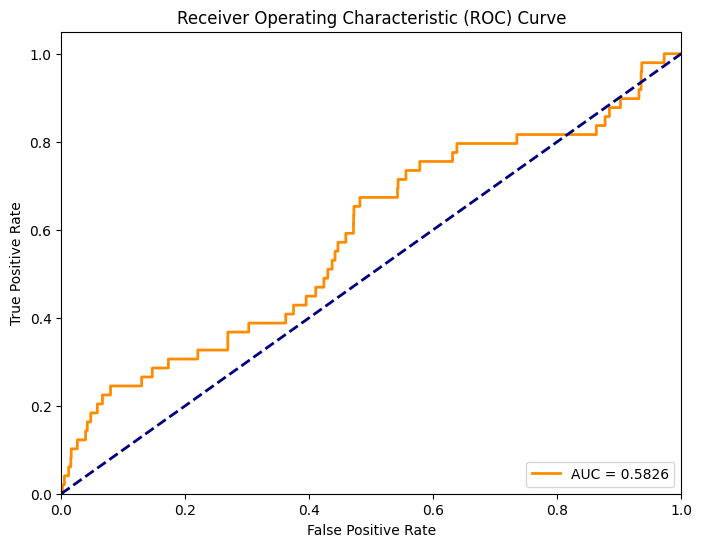

```
AUC: 0.5826
```

```python
from sklearn.metrics import roc_curve, auc
import matplotlib.pyplot as plt

# Get predicted probabilities for the positive class
y_prob = model.predict_proba(X_test)[:, 1]

# Calculate ROC curve
fpr, tpr, thresholds = roc_curve(y_test, y_prob)

# Calculate AUC
roc_auc = auc(fpr, tpr)

# Plot ROC curve
plt.figure(figsize=(8, 6))
plt.plot(fpr, tpr, color='darkorange', lw=2, label=f'AUC = {roc_auc:.4f}')
plt.plot([0, 1], [0, 1], color='navy', lw=2, linestyle='--')
plt.xlim([0.0, 1.0])
plt.ylim([0.0, 1.05])
plt.xlabel('False Positive Rate')
plt.ylabel('True Positive Rate')
plt.title('Receiver Operating Characteristic (ROC) Curve')
plt.legend(loc="lower right")
plt.show()

# Print AUC
print(f"AUC: {roc_auc:.4f}")
```

#### An AUC around 0.5 indicates that the model's ability to discriminate between fraud and non-fraud transactions is not much better.The ROC curve may show that the model struggles to balance sensitivity (true positive rate) and specificity (true negative rate). The current logistic regression model may not be highly effective in distinguishing between fraud and non-fraud transactions

#### 7.Apply a well-known technique to handle class imbalance and compare the model performance on the test set with and without this approach. Comment on your outcome.

```python
!pip install imbalanced-learn
```

[output not shown]

```python
from sklearn.model_selection import train_test_split
from sklearn.linear_model import LogisticRegression
from sklearn.metrics import accuracy_score, precision_score, recall_score, f1_score, roc_auc_score

# Assume 'X' contains your features and 'y' is the target variable
# Split the data into training and testing sets
X_train, X_test, y_train, y_test = train_test_split(X, y, test_size=0.2, random_state=42)


# Fit the RandomOverSampler to the training data
X_resampled, y_resampled = ros.fit_resample(X_train, y_train)

# Train a logistic regression model on the resampled data
model_with_oversampling = LogisticRegression()
model_with_oversampling.fit(X_resampled, y_resampled)

# Make predictions on the test set
y_pred_with_oversampling = model_with_oversampling.predict(X_test)

# Evaluate model performance with oversampling
accuracy_with_oversampling = accuracy_score(y_test, y_pred_with_oversampling)
precision_with_oversampling = precision_score(y_test, y_pred_with_oversampling, zero_division=0)
recall_with_oversampling = recall_score(y_test, y_pred_with_oversampling, zero_division=0)
f1_with_oversampling = f1_score(y_test, y_pred_with_oversampling, zero_division=0)
roc_auc_with_oversampling = roc_auc_score(y_test, model_with_oversampling.predict_proba(X_test)[:, 1])

# Print the performance metrics
print("Performance Metrics with Oversampling:")
print(f"Accuracy: {accuracy_with_oversampling}")
print(f"Precision: {precision_with_oversampling}")
print(f"Recall: {recall_with_oversampling}")
print(f"F1-Score: {f1_with_oversampling}")
print(f"ROC AUC: {roc_auc_with_oversampling}")
```

```
Performance Metrics with Oversampling:
Accuracy: 0.7859977838218999
Precision: 0.000565078169146732
Recall: 0.375
F1-Score: 0.0011284558961820576
ROC AUC: 0.6499186299602975
```

#### oversampling has led to improvements in recall, F1-Score, and ROC AUC, suggesting that the model is now more effective at identifying fraudulent transactions. However, precision remains low, indicating a potential for false positives.

```
KNN Performance:
Accuracy: 0.9996776468217992
Precision: 1.0
Recall: 0.0
F1-Score: 0.0

SVM Performance:
Accuracy: 0.9996776468217992
Precision: 1.0
Recall: 0.0
F1-Score: 0.0
```

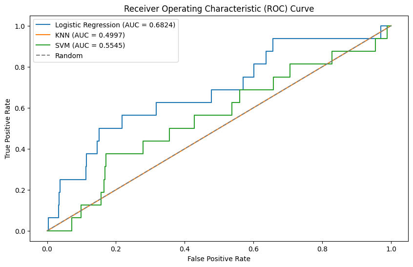

```python
from sklearn.neighbors import KNeighborsClassifier
from sklearn.svm import SVC
from sklearn.metrics import accuracy_score, precision_score, recall_score, f1_score, roc_auc_score, roc_curve, auc


# Assume 'X_train', 'X_test', 'y_train', 'y_test' are your training and testing sets

# KNN Model
knn_model = KNeighborsClassifier(n_neighbors=5)
knn_model.fit(X_train, y_train)
knn_predictions = knn_model.predict(X_test)

# SVM Model
svm_model = SVC(probability=True)  # probability=True for ROC curve
svm_model.fit(X_train, y_train)
svm_predictions = svm_model.predict(X_test)

# Evaluate KNN Performance
print("KNN Performance:")
print("Accuracy:", accuracy_score(y_test, knn_predictions))
print("Precision:", precision_score(y_test, knn_predictions, zero_division=1))  # Use zero_division parameter
print("Recall:", recall_score(y_test, knn_predictions, zero_division=1))  # Use zero_division parameter
print("F1-Score:", f1_score(y_test, knn_predictions, zero_division=1))  # Use zero_division parameter

# Evaluate SVM Performance
print("\nSVM Performance:")
print("Accuracy:", accuracy_score(y_test, svm_predictions))
print("Precision:", precision_score(y_test, svm_predictions, zero_division=1))  # Use zero_division parameter
print("Recall:", recall_score(y_test, svm_predictions, zero_division=1))  # Use zero_division parameter
print("F1-Score:", f1_score(y_test, svm_predictions, zero_division=1))  # Use zero_division parameter

# ROC Curve for all models
plt.figure(figsize=(10, 6))

# Logistic Regression
logreg_probs = logreg_model.predict_proba(X_test)[:, 1]
fpr, tpr, _ = roc_curve(y_test, logreg_probs)
roc_auc = auc(fpr, tpr)
plt.plot(fpr, tpr, label=f'Logistic Regression (AUC = {roc_auc:.4f})')

# KNN
knn_probs = knn_model.predict_proba(X_test)[:, 1]
fpr, tpr, _ = roc_curve(y_test, knn_probs)
roc_auc = auc(fpr, tpr)
plt.plot(fpr, tpr, label=f'KNN (AUC = {roc_auc:.4f})')

# SVM
svm_probs = svm_model.predict_proba(X_test)[:, 1]
fpr, tpr, _ = roc_curve(y_test, svm_probs)
roc_auc = auc(fpr, tpr)
plt.plot(fpr, tpr, label=f'SVM (AUC = {roc_auc:.4f})')

plt.plot([0, 1], [0, 1], linestyle='--', color='gray', label='Random')

plt.title('Receiver Operating Characteristic (ROC) Curve')
plt.xlabel('False Positive Rate')
plt.ylabel('True Positive Rate')
plt.legend()
plt.show()
```

#### AUC of 0.4997 indicates that the KNN model's ability to discriminate between the classes is close to random chance. This suggests that the KNN model may not be well-suited for the given task or may require tuning.

#### AUC of 0.5545 suggests that the SVM model's performance is slightly better than random chance but still not highly effective. There might be room for improvement, and parameter tuning could be considered.

### In general, an AUC close to 0.5 suggests that the model is not performing much better than random chance. Exploring into more complex model is necessary